# Problem 2: Logistic Regression and LDA

### LDA MODEL

```python
df1.head()
```

|  | Holliday_Package | Salary | age | educ | no_young_children | no_older_children | foreign |
| --- | --- | --- | --- | --- | --- | --- | --- |
| 0 | no | 48412.0 | 30.0 | 8.0 | 0.0 | 1.0 | no |
| 1 | yes | 37207.0 | 45.0 | 8.0 | 0.0 | 1.0 | no |
| 2 | no | 58022.0 | 46.0 | 9.0 | 0.0 | 0.0 | no |
| 3 | no | 66503.0 | 31.0 | 11.0 | 0.0 | 0.0 | no |
| 4 | no | 66734.0 | 44.0 | 12.0 | 0.0 | 2.0 | no |

```python
for feature in df1.columns:
    if df1[feature].dtype == 'object':
        print('\n')
        print('feature:',feature)
        print(pd.Categorical(df1[feature].unique()))
        print(pd.Categorical(df1[feature].unique()).codes)
        df1[feature] = pd.Categorical(df1[feature]).codes
```

```
feature: Holliday_Package
['no', 'yes']
Categories (2, object): ['no', 'yes']
[0 1]


feature: foreign
['no', 'yes']
Categories (2, object): ['no', 'yes']
[0 1]
```

```python
X = df1.drop('Holliday_Package',axis=1)
Y = df1.pop('Holliday_Package')
```

```python
X_train,X_test,Y_train,Y_test = model_selection.train_test_split(X,Y,test_size=0.30,random_state=1,stratify = Y)
```

```python
#Build LDA Model
clf = LinearDiscriminantAnalysis()
model=clf.fit(X_train,Y_train)
```

```python
pred_class_train = model.predict(X_train)
pred_class_test = model.predict(X_test)
```

```python
pred_class_test
```

```
array([0, 0, 0, 0, 0, 1, 0, 1, 1, 0, 0, 1, 1, 0, 1, 1, 1, 0, 0, 0, 0, 0,
       0, 0, 1, 1, 0, 0, 1, 1, 0, 0, 1, 0, 1, 0, 1, 0, 0, 1, 0, 1, 1, 0,
       0, 0, 0, 1, 1, 0, 0, 0, 0, 0, 1, 1, 0, 1, 0, 0, 0, 0, 0, 0, 0, 0,
       0, 0, 0, 0, 0, 0, 0, 0, 1, 1, 0, 1, 1, 0, 0, 0, 0, 1, 0, 1, 0, 1,
       0, 1, 0, 1, 0, 0, 0, 1, 0, 0, 0, 0, 0, 1, 0, 0, 0, 0, 0, 1, 0, 0,
       0, 1, 1, 0, 1, 1, 0, 0, 0, 0, 0, 1, 0, 0, 0, 0, 0, 0, 0, 0, 0, 0,
       0, 0, 0, 0, 0, 1, 1, 1, 0, 0, 0, 0, 0, 0, 0, 0, 0, 0, 0, 1, 0, 0,
       0, 0, 1, 0, 1, 0, 0, 1, 0, 0, 0, 0, 0, 0, 0, 0, 0, 1, 0, 1, 0, 0,
       1, 0, 1, 1, 0, 0, 0, 1, 1, 0, 0, 0, 0, 0, 1, 1, 0, 0, 0, 1, 1, 0,
       0, 0, 1, 0, 0, 0, 0, 1, 0, 0, 0, 0, 0, 1, 1, 0, 1, 0, 1, 0, 0, 0,
       0, 0, 1, 0, 1, 1, 0, 0, 0, 0, 1, 0, 0, 1, 0, 0, 0, 1, 1, 0, 0, 0,
       1, 0, 0, 0, 1, 0, 1, 1, 1, 0, 1, 0, 0, 0, 0, 1, 0, 0, 0, 0],
      dtype=int8)
```

```python
# Training Data Probability Prediction
pred_prob_train = model.predict_proba(X_train)

# Test Data Probability Prediction
pred_prob_test = model.predict_proba(X_test)
```

```python
lda_train_acc = model.score(X_train,Y_train)
lda_train_acc
```

```
0.6327868852459017
```

```python
print(classification_report(Y_train, pred_class_train))
```

```
              precision    recall  f1-score   support

           0       0.62      0.80      0.70       329
           1       0.65      0.44      0.52       281

    accuracy                           0.63       610
   macro avg       0.64      0.62      0.61       610
weighted avg       0.64      0.63      0.62       610
```

```python
confusion_matrix(Y_train, pred_class_train)
```

```
array([[263,  66],
       [158, 123]], dtype=int64)
```

```python
lda_metrics=classification_report(Y_train, pred_class_train,output_dict=True)
df=pd.DataFrame(lda_metrics).transpose()
lda_train_f1=round(df.loc["1"][2],2)
lda_train_recall=round(df.loc["1"][1],2)
lda_train_precision=round(df.loc["1"][0],2)
print ('lda_train_precision ',lda_train_precision)
print ('lda_train_recall ',lda_train_recall)
print ('lda_train_f1 ',lr_train_f1)
```

[output not shown]

```python
lda_test_acc = model.score(X_test,Y_test)
lda_test_acc
```

```
0.6564885496183206
```

```python
print(classification_report(Y_test, pred_class_test))
```

```
              precision    recall  f1-score   support

           0       0.64      0.83      0.72       142
           1       0.69      0.45      0.55       120

    accuracy                           0.66       262
   macro avg       0.67      0.64      0.63       262
weighted avg       0.66      0.66      0.64       262
```

```python
confusion_matrix(Y_test, pred_class_test)
```

```
array([[118,  24],
       [ 66,  54]], dtype=int64)
```

```
0.1

Accuracy Score 0.4607
F1 Score 0.6308

Confusion Matrix
```

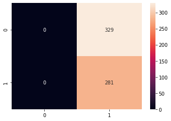

```
0.2

Accuracy Score 0.4738
F1 Score 0.6365

Confusion Matrix
```

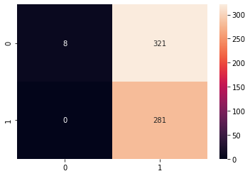

```
0.3

Accuracy Score 0.5344
F1 Score 0.6485

Confusion Matrix
```

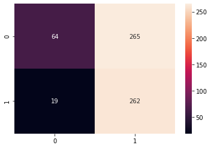

```
0.4

Accuracy Score 0.5787
F1 Score 0.6088

Confusion Matrix
```

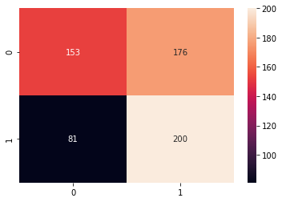

```
0.5

Accuracy Score 0.6328
F1 Score 0.5234

Confusion Matrix
```

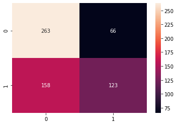

```
0.6

Accuracy Score 0.6213
F1 Score 0.446

Confusion Matrix
```

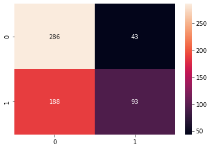

```
0.7

Accuracy Score 0.5869
F1 Score 0.2455

Confusion Matrix
```

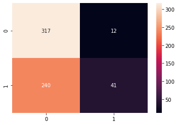

```
0.8

Accuracy Score 0.541
F1 Score 0.0071

Confusion Matrix
```

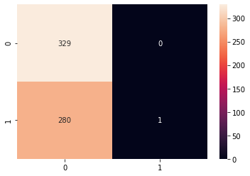

```
0.9

Accuracy Score 0.5393
F1 Score 0.0

Confusion Matrix
```

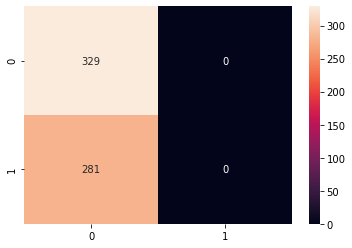

```python
for j in np.arange(0.1,1,0.1):
    custom_prob = j #defining the cut-off value of our choice
    custom_cutoff_data=[]#defining an empty list
    for i in range(0,len(Y_train)):#defining a loop for the length of the test data
        if np.array(pred_prob_train[:,1])[i] > custom_prob:#issuing a condition for our probability values to be
            #greater than the custom cutoff value
            a=1#if the probability values are greater than the custom cutoff then the value should be 1
        else:
            a=0#if the probability values are less than the custom cutoff then the value should be 0
        custom_cutoff_data.append(a)#adding either 1 or 0 based on the condition to the end of the list defined by us
    print(round(j,3),'\n')
    print('Accuracy Score',round(metrics.accuracy_score(Y_train,custom_cutoff_data),4))
    print('F1 Score',round(metrics.f1_score(Y_train,custom_cutoff_data),4),'\n')
    plt.figure(figsize=(6,4))
    print('Confusion Matrix')
    sns.heatmap(metrics.confusion_matrix(Y_train,custom_cutoff_data),annot=True,fmt='.4g'),'\n\n'
    plt.show();
```

```
AUC for the Training Data: 0.661
AUC for the Test Data: 0.675
```

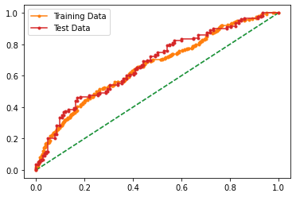

```python
# AUC and ROC for the training data


# calculate AUC
lda_train_auc = metrics.roc_auc_score(Y_train,pred_prob_train[:,1])
print('AUC for the Training Data: %.3f' % lda_train_auc)

#  calculate roc curve
fpr, tpr, thresholds = metrics.roc_curve(Y_train,pred_prob_train[:,1])
plt.plot([0, 1], [0, 1], linestyle='--')
# plot the roc curve for the model
plt.plot(fpr, tpr, marker='.',label = 'Training Data')


# AUC and ROC for the test data

# calculate AUC
lda_test_auc = metrics.roc_auc_score(Y_test,pred_prob_test[:,1])
print('AUC for the Test Data: %.3f' % lda_test_auc)

#  calculate roc curve
fpr, tpr, thresholds = metrics.roc_curve(Y_test,pred_prob_test[:,1])
plt.plot([0, 1], [0, 1], linestyle='--')
# plot the roc curve for the model
plt.plot(fpr, tpr, marker='.',label='Test Data')
# show the plot
plt.legend(loc='best')
plt.show()
```

```python
lda_metrics=classification_report(Y_test, pred_class_test,output_dict=True)
df=pd.DataFrame(lda_metrics).transpose()
lda_test_f1=round(df.loc["1"][2],2)
lda_test_recall=round(df.loc["1"][1],2)
lda_test_precision=round(df.loc["1"][0],2)
print ('lda_test_precision ',lda_test_precision)
print ('lda_test_recall ',lda_test_recall)
print ('lda_test_f1 ',lda_test_f1)
```

```
lda_test_precision  0.69
lda_test_recall  0.45
lda_test_f1  0.55
```

```python
index=['Accuracy', 'AUC', 'Recall','Precision','F1 Score']
data = pd.DataFrame({'LR Train':[lr_train_acc,lr_train_auc,lr_train_recall,lr_train_precision,lr_train_f1],
        'LR Test':[lr_test_acc,lr_test_auc,lr_test_recall,lr_test_precision,lr_test_f1],
       'LDA Train':[lda_train_acc,lda_train_auc,lda_train_recall,lda_train_precision,lda_train_f1],
        'LDA Test':[lda_test_acc,lda_test_auc,lda_test_recall,lda_test_precision,lda_test_f1],},index=index)
round(data,2)
```

|  | LR Train | LR Test | LDA Train | LDA Test |
| --- | --- | --- | --- | --- |
| Accuracy | 0.63 | 0.66 | 0.63 | 0.66 |
| AUC | 0.66 | 0.68 | 0.66 | 0.68 |
| Recall | 0.45 | 0.45 | 0.44 | 0.45 |
| Precision | 0.65 | 0.69 | 0.65 | 0.69 |
| F1 Score | 0.53 | 0.55 | 0.52 | 0.55 |

### 2.4 Basis on these predictions, what are the insights and recommendations.Please explain and summarise the various steps performed in this project. There should be proper business interpretation and actionable insights present.

We performed both Logestic regression and LDA model, all performace metrices reacts in similar way. We need additional data to predict better.

In EDA it clear ly shows age 30 to 50 opted for Holiday packages. But in age 50 to 60 employes are not opted for holiday packages.

People of a lower age even from a lower salary bracket choose holiday more than people from a higher age group.

Salary higher than 150000 are not opted for holiday packages. so we need to deep dive to get better solution. Basically aged person not opted for holiday packages so we need to offer some destination place. We need discuss with those employee to get better idea.